# Transforming Health and Social Care Publications in Scotland

September 4, 2018  
Slides: https://github.com/NHS-NSS-transforming-publications/rssconf2018

## Background

- The Information Services Division (ISD) of NHS Scotland has a long history of producing official and national statistics.
- We produce around 200 publications each year.
- Traditional publication format is a **static pdf document** with accompanying **excel tables**.
- Production uses **proprietary software** and is **time-consuming**, involving extensive manual formatting and checking.

[figure not shown]

## Vision

[figure not shown]

## Initial User Engagament

- Focus groups and interviews with over 10 different user groups.
- Determined user experiences of existing product and how the new product deisgn could meet their needs.

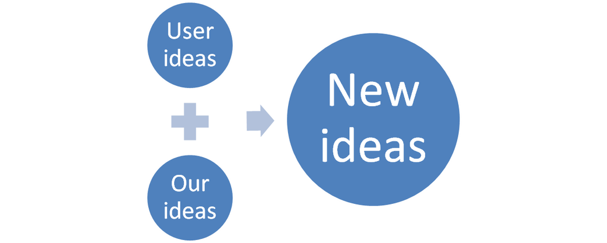

## Personas

[figure not shown]

[figure not shown]

- High-level user groups:
  - Curious
  - Focused
  - Detailed
  - Diggers

## Minimum Viable Product (MVP)

[figure not shown]

## MVP: Data summary

[figure not shown]

## MVP: Trend data

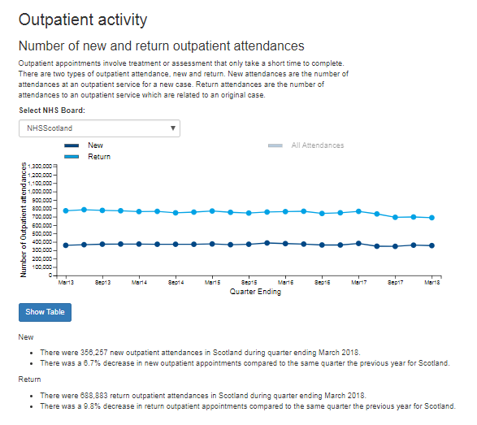

## MVP: Data explorer

[figure not shown]

## MVP: Data files

[figure not shown]

## MVP: Further Information

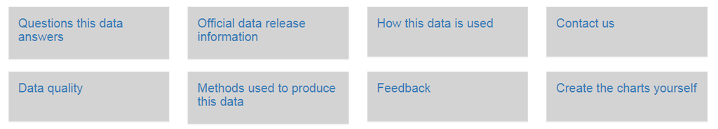

- Includes:
  - metadata
  - methods and data quality issues
  - link to GitHub repo with data explorer code
  - feedback form and contact details

## User Feedback and Testing

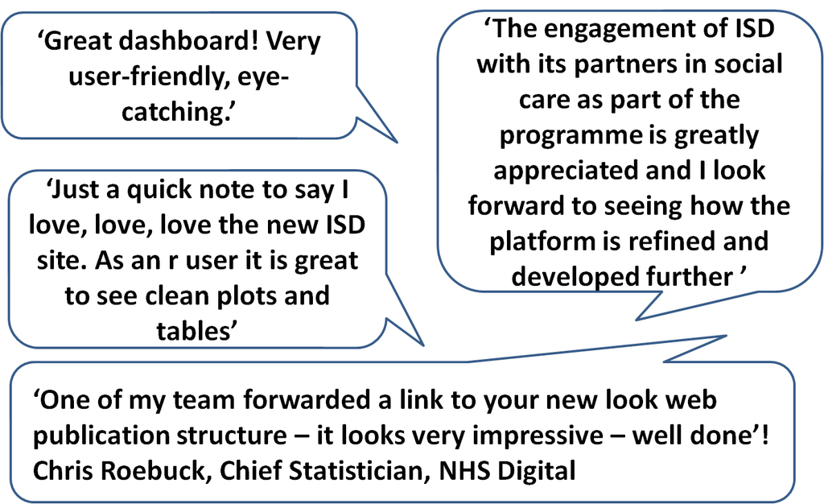

## Next Steps

- **Psychiatric Hospital Activity publication** to be released 25 September 2018.
- **Thematic** approach to publications.
- Re-design of [Data quality](https://www.isdscotland.org/Health-Topics/Hospital-Care/Publications/2018-06-26/Acute-Hospital-Publication/data-quality/) page.
- Automate production process ([Reproducible Analytical Pipeline](https://ukgovdatascience.github.io/rap_companion/)).

[figure not shown]

## Thank You

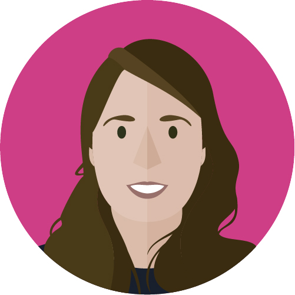

[figure not shown]

@price_AH

[figure not shown]

annahprice

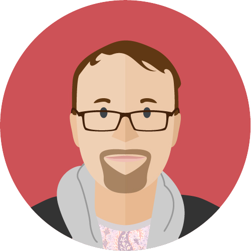

[figure not shown]

@KingTyjet92

[figure not shown]

davidc92

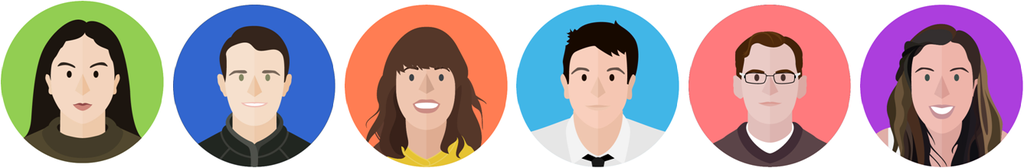

Acute Activity publication: https://bit.ly/2PhLYbL

Transforming Publishing on GitHub:  
https://github.com/NHS-NSS-transforming-publications

ISD on GitHub: https://github.com/Health-SocialCare-Scotland

ISD on Twitter: @NHSNSS